# Data analysis and visualization using R (1)

Complex data types

Michiel Noback

September 2019

# Complex datatypes and IO

**Contents**

- Factors
- Lists
- Data frames
- Reading dataframes from file (first iteration)
- Plotting with dataframes

# Nominal & Ordinal scales: Factors

# Factors

- Although factors are not actually a complex datatype I saved them because they have some strange behaviour.
- Factors are used to represent different levels of a variable.
- For instance:
  - eye color (brown, blue, green)
  - weight class (underweight, normal, obese)
  - autism spectrum (none, sligh, heavy)

# Nominal or Ordinal?

- Factors are used to represent data in nominal and ordinal scales
- Nominal has no order (e.g. eye color)
- Ordinal has order (e.g. autism spectrum), but can not be added to or subtracted from
- these functions are relevant
  - `factor()`
  - `as.factor()`

# factor or as.factor?

- `as.factor()` is a wrapper for `factor()`
- the difference lies in behaviour with input factors: `factor` will omit unused levels

```r
x <- factor(c("a", "b"), levels = c("a", "b", "c"))
x
factor(x)
as.factor(x)
```

```
[1] a b
Levels: a b c
[1] a b
Levels: a b
[1] a b
Levels: a b c
```

# Character to factor

- Suppose you have surveyed the eye color of your class room and found these values

```r
eye_colors <- c("green", "blue", "brown", "brown", "blue",
    "brown", "brown", "brown", "blue", "brown", "green",
    "brown", "brown", "blue", "blue", "brown")
```

- next you would like to plot or tabulate these findings

# Plot character data

- Simply plotting gives an error

```r
plot(eye_colors)
```

```
Error in plot.window(...): need finite 'ylim' values
```

# Plot factor data

- Plotting a character vector converted to a factor is easy

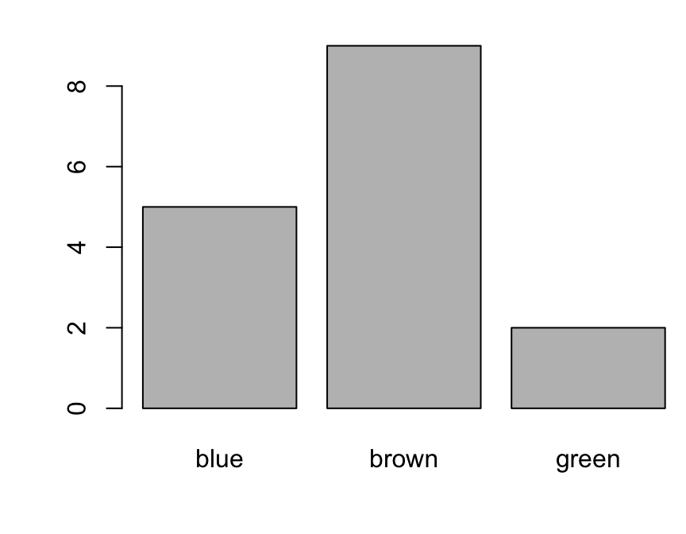

```r
eye_colors <- as.factor(eye_colors)
plot(eye_colors)
```

# Tabulate and sum factor data

- Factors are also really easy to tabulate and filter

```r
table(eye_colors)
```

```
eye_colors
 blue brown green
    5     9     2
```

```r
sum(eye_colors == "blue")
```

```
[1] 5
```

# Defining levels

- Especially when working with ordinal scales, defining the order of the factors (levels) is useful
- By default, R uses the natural ordering (numerical/alphabetical)
- You can even define missing levels, as shown in the next slide

# Factors with ordinal scale

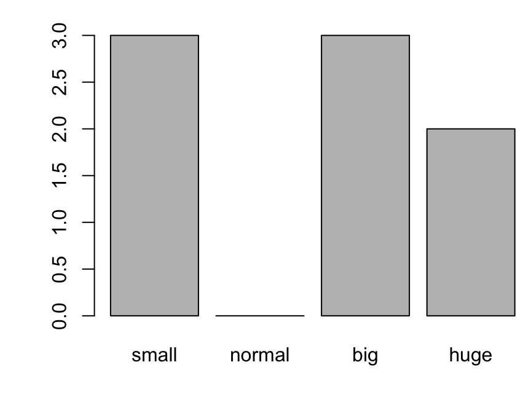

```r
classSizes <- factor(c("big", "small", "huge", "huge",
    "small","big","small","big"),
    levels = c("small", "normal", "big", "huge"),
    ordered = TRUE)
plot(classSizes)
```

# Calculations with factors

- When you have factor, you can do some calulations with it
- Comparators only work with ordinal scale
- sum() works with both

```r
classSizes < "big" ## only with in Ordinal scale
```

```
[1] FALSE  TRUE FALSE FALSE  TRUE FALSE  TRUE FALSE
```

```r
sum(classSizes == "huge")
```

```
[1] 2
```

# What doesn’t work

```r
x <- factor(c(3, 4, 5, 4))
x + 1
```

```
[1] NA NA NA NA
```

```r
as.integer(x) + 1
```

```
[1] 2 3 4 3
```

```r
as.integer(levels(x)) + 1
```

```
[1] 4 5 6
```

# Convert factor back to numeric

The only way to get the numbers back with numeric factors is by using this trick

```r
x
```

```
[1] 3 4 5 4
Levels: 3 4 5
```

```r
as.integer(levels(x))[x]
```

```
[1] 3 4 5 4
```

# Convert existing factors

When you already have an unorderd factor, you can make it ordered by using the function `ordered()` together with the levels vector

```r
classSizes <- factor(c("big", "small", "huge", "huge",
    "small", "big", "small", "big"))
classSizes <- ordered(classSizes,
                    levels = c("small", "big", "huge"))
classSizes
```

```
[1] big   small huge  huge  small big   small big
Levels: small < big < huge
```

# Working with factors

Factors are used all the time e.g. for defining treated/untreated. That’s why R knows how to deal with them so well:

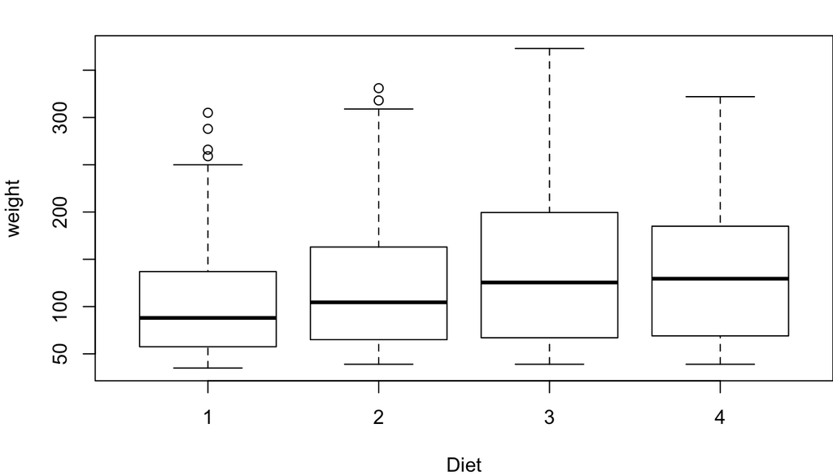

```r
with(ChickWeight, plot(weight ~ Diet))
```

# Lists

# Lists

- A list is an ordered collection of vectors
- These vectors can have **differing types** and **differing lengths**
- Create a list with
  - `list(element1, element2, ...)` or
  - `list(name1 = element1, name2 = element2, ...)`
- Accessing list elements
  - double brackets: `[[<index>]]` or `[[<name>]]`
  - dollar sign `$` but only if the elements are named

# Lists without names

```r
x <- c(2, 3, 1);  y <- c("foo", "bar")
l <- list(x, y); l
```

```
[[1]]
[1] 2 3 1

[[2]]
[1] "foo" "bar"
```

```r
l[[2]]
```

```
[1] "foo" "bar"
```

# Chaining selections

In R, selections are often *chained*. Here, the second vector element of the second list element is selected.

```r
l
l[[2]][2]
#same as
l[[c(2, 2)]]
```

```
[[1]]
[1] 2 3 1

[[2]]
[1] "foo" "bar"

[1] "bar"
[1] "bar"
```

# Selecting multiple elements

When you need multiple elements of a list, use *single brackets*

```r
l[c(1,2,1)]
```

```
[[1]]
[1] 2 3 1

[[2]]
[1] "foo" "bar"

[[3]]
[1] 2 3 1
```

# Named list elements

- List can also have named elements
- This is the preferred way to create and use them

```r
x <- c(2, 3, 1)
y <- c("foo", "bar")
l <- list("numbers" = x, "words" = y)
l
```

```
$numbers
[1] 2 3 1

$words
[1] "foo" "bar"
```

Accessing named elements can be done in three ways

```r
l[[2]]        # index
```

```
[1] "foo" "bar"
```

```r
l[["words"]]  # name of element with double brackets
```

```
[1] "foo" "bar"
```

```r
l$words       # name of element with dollar sign
```

```
[1] "foo" "bar"
```

# Use of a variable as selector

Accessing named elements has its limitations

```r
select <- "words"
l[[select]] ## OK
```

```
[1] "foo" "bar"
```

```r
l$select ##fails - no element with name "select"
```

# Single versus double brackets

- Single brackets on a list returns a list
- Double brackets and `$` return a vector

```r
l[2]
```

```
$words
[1] "foo" "bar"
```

```r
l[[2]]
```

```
[1] "foo" "bar"
```

```r
l$words
```

```
[1] "foo" "bar"
```

# Chaining of selectors can become awkward

```r
l[2]["words"][1]$words  ## mind****
```

```
[1] "foo" "bar"
```

# Dataframes

# data.frame rules all

- The dataframe is the real data workhorse of R
- A dataframe is a structure much like an Excel sheet
  - variables are in columns - all elements are of the same type
  - examples (observations) are in rows - can have differing types
- They are created using the `data.frame()` function in the same way as the `list` function:
  - `data.frame(column1 = vector1, column2 = vector2, ...)`

# A first dataframe

```r
geneNames <- c("P53","BRCA1","VAMP1", "FHIT")
sig <- c(TRUE, TRUE, FALSE, FALSE)
meanExp <- c(4.5, 7.3, 5.4, 2.4)
genes <- data.frame(
    "name" = geneNames,
    "significant" = sig,
    "expression" = meanExp)
genes
```

```
   name significant expression
1   P53        TRUE        4.5
2 BRCA1        TRUE        7.3
3 VAMP1       FALSE        5.4
4  FHIT       FALSE        2.4
```

# The dataframe “grid”

- Here you can see the structure of a dataframe - each column has a single datatype but rows can have differing content.
- In essence, a dataframe is a *list of vectors of the same length*.

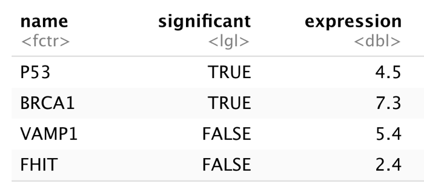

# Selections on dataframes

- Select a column using `$`
- For other selections use this form:
- `my_data_frame[row_selection, col_selection]`
- where `row_selection` and `col_selection` can be
  - a numerical vector of length 1 or more
  - a logical vector of length 1 or more
  - empty (to select all)

```r
genes[2,1]          #row 2, column 1
```

```
[1] BRCA1
Levels: BRCA1 FHIT P53 VAMP1
```

```r
genes[2, 1:2]     #row 2, columns 1 and 2
```

```
   name significant
2 BRCA1        TRUE
```

```r
genes[2, c(1, 3)] #row 2, column 1 and 3
```

```
   name expression
2 BRCA1        7.3
```

```r
genes$name                        #column "name"
```

```
[1] P53   BRCA1 VAMP1 FHIT
Levels: BRCA1 FHIT P53 VAMP1
```

```r
genes[, c("name", "expression")]    #columns "name" and "expression"
```

```
   name expression
1   P53        4.5
2 BRCA1        7.3
3 VAMP1        5.4
4  FHIT        2.4
```

```r
genes[, 1:2]    #columns 1 and 2
```

```
   name significant
1   P53        TRUE
2 BRCA1        TRUE
3 VAMP1       FALSE
4  FHIT       FALSE
```

```r
genes[1:2, ]  #row 1 and 2
```

```
   name significant expression
1   P53        TRUE        4.5
2 BRCA1        TRUE        7.3
```

R will recycle selectors, and you can select an element as often as you want.

```r
genes[c(T, F), 1]   #every uneven row, column 1
```

```
[1] P53   VAMP1
Levels: BRCA1 FHIT P53 VAMP1
```

```r
genes[c(1, 1, 1, 2), ]  #three times row 1 and row 2
```

```
     name significant expression
1     P53        TRUE        4.5
1.1   P53        TRUE        4.5
1.2   P53        TRUE        4.5
2   BRCA1        TRUE        7.3
```

# A dataframe is list(-ish)

```r
genes[["name"]] ## select column w. double brackets
```

```
[1] P53   BRCA1 VAMP1 FHIT
Levels: BRCA1 FHIT P53 VAMP1
```

```r
class(genes) ## it is NOT a list though
```

```
[1] "data.frame"
```

```r
str(genes)
```

```
'data.frame':   4 obs. of  3 variables:
 $ name       : Factor w/ 4 levels "BRCA1","FHIT",..: 3 1 4 2
 $ significant: logi  TRUE TRUE FALSE FALSE
 $ expression : num  4.5 7.3 5.4 2.4
```

# Reading from file

# Loading data frames from file

- Usually data in dataframes is loaded from file
- The most common data transfer & storage format is text (tab- or comma-delimited)
- Here is an example data set in a file (“whale_selenium.txt”) where the separator is a space character

  ```
  whale liver.Se tooth.Se
  1 6.23 140.16
  2 6.79 133.32
  3 7.92 135.34
  ...
  19 41.23 206.30
  20 45.47 141.31
  ```

# Load data with `read.table()`

```r
whale.selenium <- read.table("data/whale_selenium.txt")
head(whale.selenium)
```

```
     V1       V2       V3
1 whale liver.Se tooth.Se
2     1     6.23   140.16
3     2     6.79   133.32
4     3     7.92   135.34
5     4     8.02   127.82
6     5     9.34   108.67
```

- When loading the data in the standard way,
  - there is no special consideration for the header line
  - the separator is assumed to be a space
  - the decimal is assumed to be a dot “.”

# Pass the correct format specs

- Here, it is specified that
  - the first line is a header with column names
  - the first column contains the row names

```r
whale.selenium <- read.table(
    file = "data/whale_selenium.txt",
    header = TRUE,
    row.names = 1)
```

# What is in that dataframe?

```r
head(whale.selenium, n=4) #have a peek
```

```
  liver.Se tooth.Se
1     6.23   140.16
2     6.79   133.32
3     7.92   135.34
4     8.02   127.82
```

```r
str(whale.selenium) #what is the structure?
```

```
'data.frame':   20 obs. of  2 variables:
 $ liver.Se: num  6.23 6.79 7.92 8.02 9.34 ...
 $ tooth.Se: num  140 133 135 128 109 ...
```

# A summary

```r
summary(whale.selenium) ## a 6-number summary of each column
```

```
    liver.Se         tooth.Se
 Min.   : 6.230   Min.   :108.7
 1st Qu.: 9.835   1st Qu.:134.8
 Median :14.905   Median :143.4
 Mean   :20.685   Mean   :156.6
 3rd Qu.:33.633   3rd Qu.:175.1
 Max.   :45.470   Max.   :245.1
```

# Various helper methods

```r
dim(whale.selenium)
```

```
[1] 20  2
```

```r
ncol(whale.selenium)
```

```
[1] 2
```

```r
nrow(whale.selenium)
```

```
[1] 20
```

```r
names(whale.selenium) ## same as colnames()
```

```
[1] "liver.Se" "tooth.Se"
```

# Plot for visual inspection

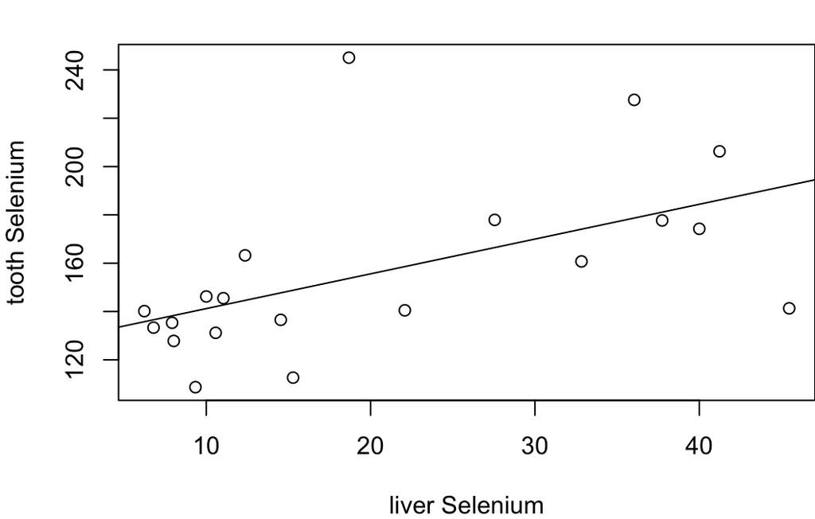

```r
plot(
    whale.selenium$liver.Se, whale.selenium$tooth.Se,
    xlab = "liver Selenium", ylab = "tooth Selenium")
abline(lm(whale.selenium$tooth.Se ~
              whale.selenium$liver.Se))
```

# Advanced file reading

- This is absolutely not the whole story!
- The file reading topic will addressed again in a later presentation.

# Dataframe manipulations

# Changing column names

```r
names(whale.selenium) <- c("liver", "tooth")
head(whale.selenium, n=2)
```

```
  liver  tooth
1  6.23 140.16
2  6.79 133.32
```

```r
##or
colnames(whale.selenium) <- c("pancreas", "colon")
head(whale.selenium, n=2)
```

```
  pancreas  colon
1     6.23 140.16
2     6.79 133.32
```

# Adding columns

Add a column by simply specifying its name, or use `cbind`

```r
## add simulated stomach data
whale.selenium$stomach <- rnorm(nrow(whale.selenium), 42, 6)
head(whale.selenium, n=2)
```

[output not shown]

```r
cbind(whale.selenium,
      "brain" = rnorm(nrow(whale.selenium), 10, 2))
```

[output not shown]

# Adding rows: `rbind()`

Adding rows is similar (continued on next slide)

```r
myData1 <- data.frame(colA = 1:3, colB = c("a", "b", "c"))
myData2 <- data.frame(colA = 4:5, colB = c("d", "e"))
```

```r
myDataComplete <- rbind(myData1, myData2)
myDataComplete
```

```
  colA colB
1    1    a
2    2    b
3    3    c
4    4    d
5    5    e
```

Note that the column names of both dataframes need to match for this operation to succeed!

# Selections with `subset()`

# `subset()` as alternative to brackets

- You can also use `subset()` to make both **column** and **row selections**
- This is an alternative to `[ , ]`
- Note that you don’t even need to use quotes

```r
##select rows for which Solar.R is available
head(subset(airquality, subset = !is.na(Solar.R)))
```

```
  Ozone Solar.R Wind Temp Month Day
1    41     190  7.4   67     5   1
2    36     118  8.0   72     5   2
3    12     149 12.6   74     5   3
4    18     313 11.5   62     5   4
7    23     299  8.6   65     5   7
8    19      99 13.8   59     5   8
```

Select two columns only

```r
head(subset(airquality, select = c(Ozone, Solar.R)))
```

```
  Ozone Solar.R
1    41     190
2    36     118
3    12     149
4    18     313
5    NA      NA
6    28      NA
```

Combine row and colum selection

```r
head(subset(airquality,
            subset = !is.na(Solar.R),
            select = c(Ozone, Solar.R)))
```

```
  Ozone Solar.R
1    41     190
2    36     118
3    12     149
4    18     313
7    23     299
8    19      99
```

Shorthand notation

```r
subset(airquality, Day == 1, select = -Temp)
```

```
    Ozone Solar.R Wind Month Day
1      41     190  7.4     5   1
32     NA     286  8.6     6   1
62    135     269  4.1     7   1
93     39      83  6.9     8   1
124    96     167  6.9     9   1
```

subset() can be used more sophisticated; just GIYF